# Neural PCA/Compression in R

In this document I will show a small experiment that shows how a neural network can be used as a pca-algorithm. It should also help explain how neural networks work and why neural networks can be such a powerful machine learning algorithm.

The code will be written in R and needs the following dependencies.

### Packages Used

```r
library(RSNNS)
```

```r
library(ggplot2)
library(devtools)
library(reshape)
library(parallel)
source_url('https://gist.githubusercontent.com/fawda123/7471137/raw/466c1474d0a505ff044412703516c34f1a4684a5/nnet_plot_update.r')
```

```
## SHA-1 hash of file is 74c80bd5ddbc17ab3ae5ece9c0ed9beb612e87ef
```

### Generating Bits

I will start out by generation random bits as data in a data frame.

```r
set.seed(1)
num.vars = 6
num.obs = 500
df = data.frame(replicate(num.vars,sample(0:1,num.obs,rep=TRUE)))
head(df)
```

```
##   X1 X2 X3 X4 X5 X6
## 1  0  1  1  0  1  1
## 2  0  1  1  1  1  0
## 3  1  1  0  0  1  1
## 4  1  1  1  1  0  0
## 5  0  0  0  0  0  1
## 6  1  1  0  0  0  0
```

This bits will then be used as input **and** output for a neural network. The goal is to see if a neural network can be trained to fit the data back into its original format while only using a limited amount of nodes in the hidden layer. Such a neural network might look like so:

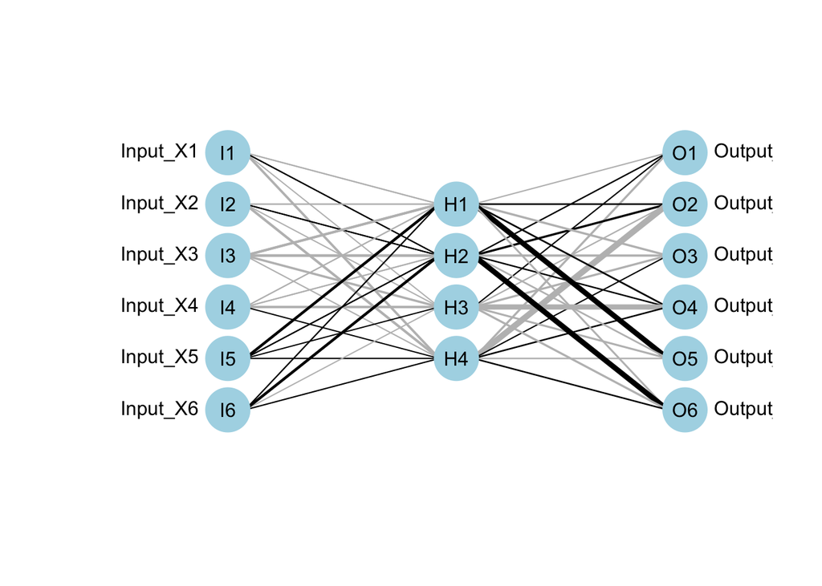

```r
mod = mlp(df, df, size=c(4))
plot.nnet(mod)
```

We can check the performace of such a neural network.

```r
bit.acc = sum( round(mod$fitted.values) == df ) / sum( df == df )
row.acc = sum(rowSums(round(mod$fitted.values) == df) == 6)/nrow(df)
cat(bit.acc, row.acc)
```

```
## 0.9193333 0.582
```

Notice that in this case we have about 91% of the bits estimated correctly and about 58% of the rows estimated correctly. That means that we are able to maintain almost 60% of the variance in this dataset by only using 4 hidden nodes (out of 6 total data sources). This is interesting because right now we are using a neural network to simulate compression and it gives us an alternative to eigenvalue based principle component analysis.

### Repeating for different network sizes

```r
simulation = function(df, num.sims){
  results = data.frame(vars = as.numeric(c()), acc = as.numeric(c()), type=as.factor(c()))
  num.vars = ncol(df)
  for(i in 1:num.vars){
    mclapply(1:num.sims, )
    for(j in 1:num.sims){
        # cat("hidden nodes :", i ,"sample #", j, "\n")
        mod = mlp(df, df, size=c(i))
        bit.acc = sum( round(mod$fitted.values) == df ) / sum( df == df )
        row.acc = sum(rowSums(round(mod$fitted.values) == df) == num.vars)/nrow(df)
        results = rbind(results, data.frame(vars = i, acc = bit.acc, type= "bit"))
        results = rbind(results, data.frame(vars = i, acc = row.acc, type= "row"))
      }
    }
  results
}
```

I will also need a function to plot my results.

```r
plotsim = function(results, title){
  agg = aggregate(data=results, acc ~ vars + type , FUN = mean)
  p = ggplot() + geom_point(data=results, aes(vars, acc), alpha=0.6)
  p = p + geom_line(data=agg, aes(vars, acc), alpha=0.3, size=2)
  p = p + facet_grid( . ~ type )
  p + ggtitle(title)
}
```

### Simulation 1

```r
# simulation 1, random values
num.vars = 8
num.obs = 200
df = data.frame(replicate(num.vars,sample(0:1,num.obs,rep=TRUE)))
sims = simulation(df, 5)
```

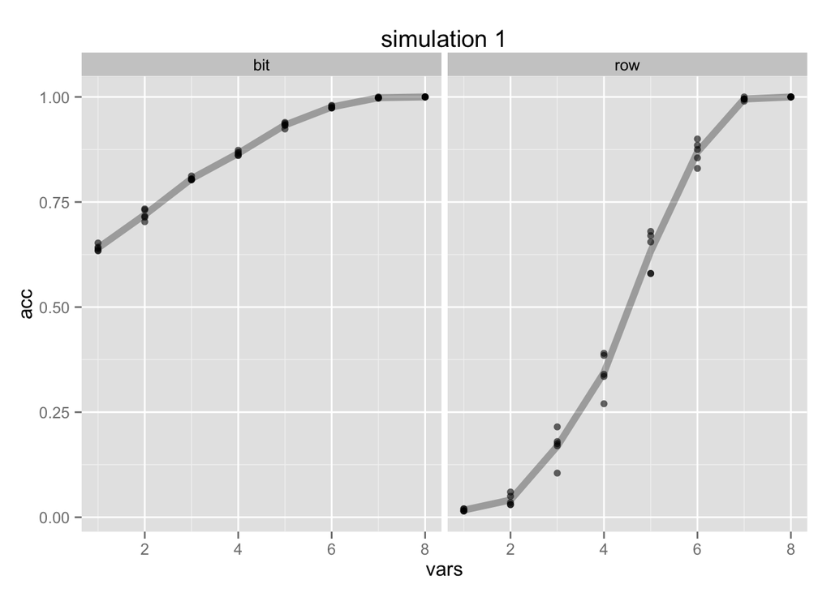

```r
plotsim(sims, 'simulation 1')
```

### Simulation 2

We will now simulate a much larger neural network.

```r
# simulation 2, random values very large dataset
num.vars = 20
num.obs = 200
df = data.frame(replicate(num.vars,sample(0:1,num.obs,rep=TRUE)))
sims = simulation(df, 5)
```

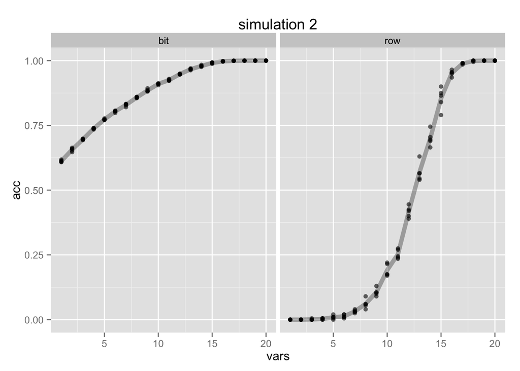

```r
plotsim(sims, 'simulation 2')
```

We see a very similar effect.